# Español 1.5: Paso preliminar

Joseph V. Casillas

# Para sobrevivir

- Para presentarnos
- Instrucciones básicas
- Para hablar con la gente

## Para presentarnos

SARA: “Hola. *Me llamo* Sara.”

AMANDA: “Hola, Sara. *Soy* Amanda.”

SARA: “Mucho gusto.”

## AMANDA: “Mucho gusto.”

- ¿Sabéis otras opciones?

## Instrucciones básicas

- **Abran/Cierren** el libro en la página...
- **Trabajad** con un compañero.
- **Escuchen** a la profesora.
- **Leed** la información.
- **Contesten** en español.
- **Escribid** vuestros nombres.

## Para hablar con la gente (1)

[figure not shown]

- ¿Cómo se dice... ?
- Con permiso/Perdón.
- Gracias... De nada.
- Sí/No

## Para hablar con la gente (2)

[figure not shown]

- Más despacio, por favor.
- ¿Puede repetir, por favor?
- ¿Qué quiere decir... ?
- ¿En qué página?
- Tengo una pregunta.

## ¿Qué se dice?

- Con un compañero, haz la actividad p-5 de la página 9.

## La clase

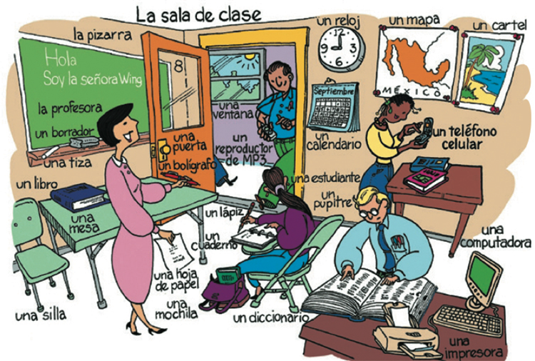

## Los sustantivos

- **Los sustantivos** son personas, lugares o cosas.
- En español tienen **género** y **número**
- ¿Puedes pensar en algunos sustantivos?

[figure not shown]

[figure not shown]

[figure not shown]

## Género

[figure not shown]

Normalmente...

- **el** libr**o**
- **la** mes**a**

Pero a veces...

- **el/la** estudiant**e**
- **el** pupitr**e**
- **la** clas**e**
- **el** relo**j**

## Número

[figure not shown]

- el libro/los libros
- la mesa/las mesas

**¡Es FÁCIL!**

## Los artículos

[figure not shown]

- Los sustantivos tienen **artículos**.
- Hay dos tipos:
  - Definidos
  - Indefinidos

## Los artículos definidos

[figure not shown]

- **el** libro, **los** libros
- **la** página, **las** páginas
- **la** mochila, **las** mochilas
- **el** cuaderno, **los** cuadernos

## Los artículos indefinidos

[figure not shown]

- **un** mapa, **unos** mapas
- **una** mesa, **unas** mesas
- **un** pupitre, **unos** pupitres
- **un**(a) estudiante **unos**(as) estudiantes

## Con un compañero...

[figure not shown]

- Haced el ejercicio P-1 de la página 4
- Haced el ejercicio P-2 de la página 4

# Descanso (10 minutos)

[figure not shown]

## El abecedario

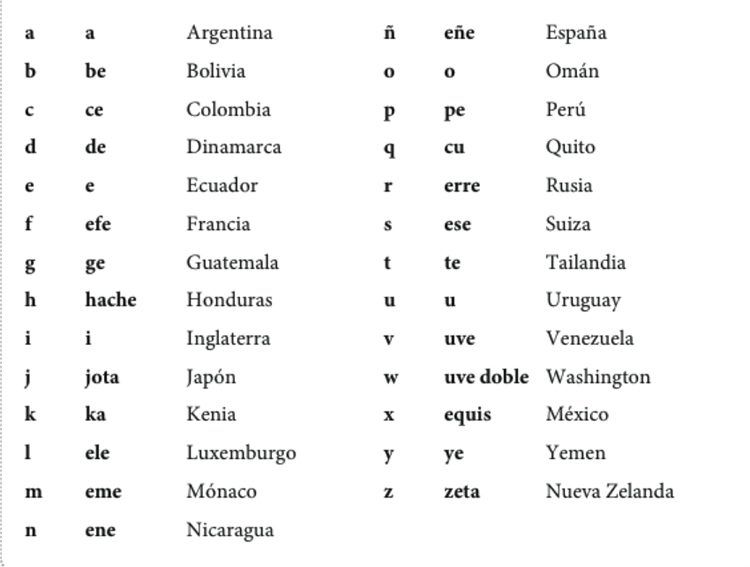

## ¿Qué es esto? ¿Cómo se escribe?

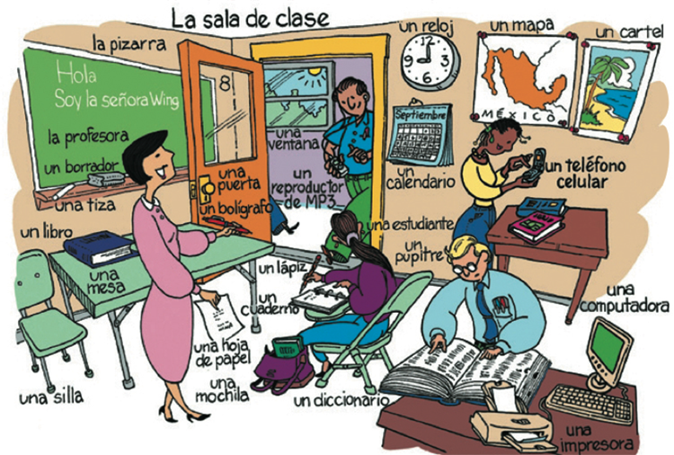

## El ahorcado

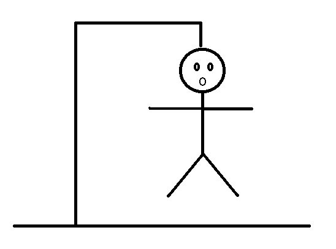

## Los números

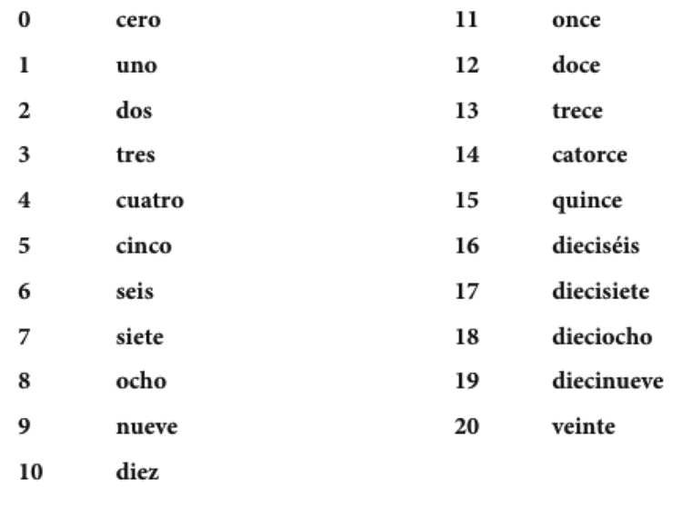

## Los números

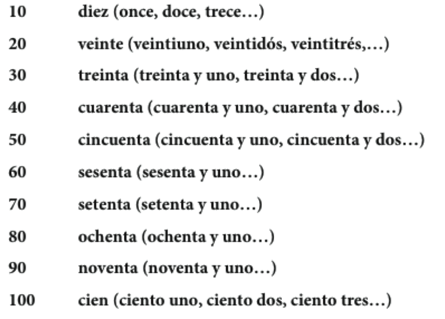

## ¿Cuántos objetos hay en la sala de clase?

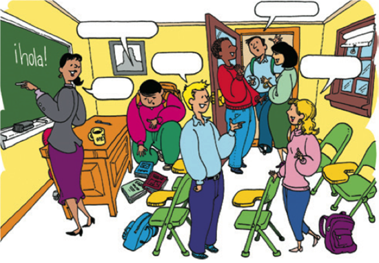

- ¿Cuántos libros? ¿Cuántas mochilas?
- ¿Cuántos pupitres? ¿Cuántos bolígrafos hay?
- ¿Cuántos estudiantes hay? ¿Cuántas sillas hay?

# Repaso

- Vocabulario
- Los sustantivos
- Los artículos
- El abecedario
- Los números

## La tarea

- Comprar el libro
- Repasar el programa
- Explorar la página moodle (go/hub/)
- Estudiar el vocabulario